# Processing & Visualising Epidemiological Data

2022-04-29

## Learning objectives

- Familiarize with **workflow** concept for data processing
- Understand the **importance** of cleaning data
- Learn **basic preparation steps** for data analyses (with a statistical perspective)
- Consider **ethical implications** of data cleaning

## The *workflow* in Data ScienceFrom R for Data Science: https://r4ds.had.co.nz/index.html

## Why is data cleaning needed?

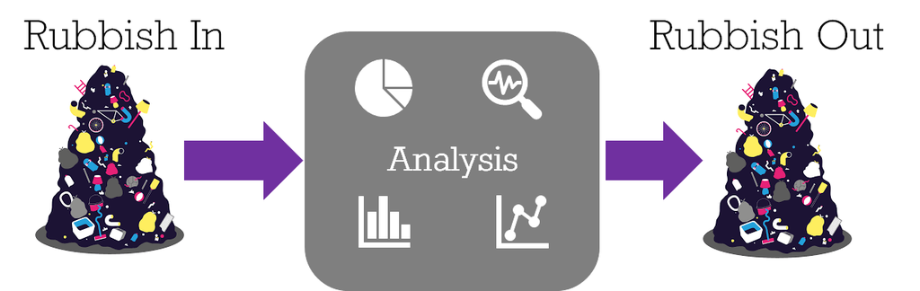

- Errors occur (despite *all*)
- Good Scientific/Clinical Practice

## What *is* data cleaning?

**Ensuring** that data are suitable for analysis

Data cleaning usually involves (cycles of):

- **Organising data (& other files)**
- **Loading and merging**
- **Understanding and formatting**
- **Deduplicating**
- **Transforming**
- **Selecting**

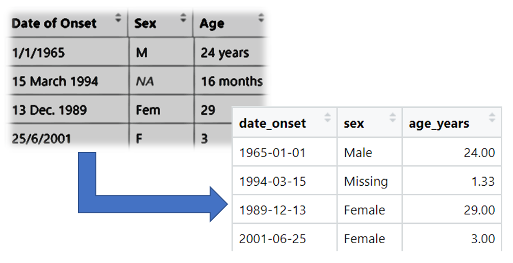

## Organising data & other files

A clear nomenclature for file names is essential to avoid errorshttps://datamanagement.hms.harvard.edu/collect/file-naming-conventions

[figure not shown]

## Organising data & other files

Have a clear nomenclature for file names:

**Examples**:

- No naming convention:  
  `FINAL_script__clean-survey Mexico City 2015.R`
- Naming convention:  
  `01.1_merge-survey-data_MC-2015.R`  
  `01.2_clean-survey-data_MC-2015.R`  
  `02.1_main-analyses_MC-2015.R`  
  `02.2_sens-analyses_MC-2015.R`  
  `03.1_make-figures_MC-2015.R`  
  `03.2_make-tables_MC-2015.R`

## Organising data & other files

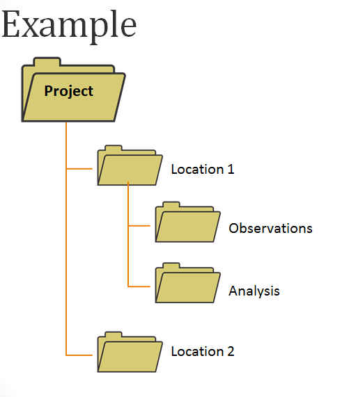

## Organising data & other files

**Consistency** and **logic** are key!

- Facilitate finding files
- Faster coding
- Easy to read for others

**Example:** all my `~/my_project/` folders tend to have my R scripts in the root folder and have (at least) 3 sub-folders:

- `~/my_project/data/`
- `~/my_project/output/`
- `~/my_project/manuscript/`

**IMPORTANT!**

- **Never** work over raw data files
- Define/locate directory(s) where raw data file(s) will be stored and consider working with copies of such files

## Organising data & other files

**SOLUTION!**

Use **R Project**https://epirhandbook.com/en/r-projects.html

- Enables work in a self-contained folder
- Keeps all scripts, data files, outputs, and history in sub-folders
- The *working directory* is the project’s root folder

More on practical…

## Loading and Merging data

**Loading data into R**:

The R 📦 **here** and **rio** facilitate defining relative file paths and importing (and exporting) data (work nicely with R Projects)

- [**rio**](https://cran.r-project.org/web/packages/rio/index.html) functions `import()` and `export()` handle many different file types (.csv, .tsv, .xlsx)
- [**here**](https://cran.r-project.org/web/packages/here/index.html) function `here()` allows description of location of files in a given R project in relation to the project’s *root directory*

Instead of having to do:

```r
my_dataset <- import("C:/User/path/to/R-project-folder/data/steps-training-data.csv"))
```

A combination of both **rio** and **here** would look like this:

```r
my_dataset <- import(here("data", "steps-training-data.csv"))
```

## Loading and Merging data

Often, epidemiological data comes from **multiple sources**:

- Questionnaire data from recruitment
- Biological sample results
- Linkage to clinical/mortality records

How do data usually look like in `R`?

`R` is an object-oriented language where **objects** are anything (constants, data structures, functions, graphs) that can be assigned to a variable

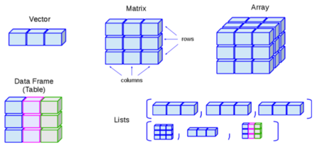

## Loading and Merging data

Three main approaches to merging or joining datasets:

- Common identifier
  - The function `left_join()` from the [**dplyr**](https://dplyr.tidyverse.org/) package is useful for merging based on common identifier (**more on practical**)
- Probabilistic
- Binding or appending

## Understanding and formatting data

**Data loaded!!!**

So…what’s up with this dataset?

Have a quick look!

- **Skim** package to see what the data looks like
- May want to ‘have a look’ *before* merging different datasets

## Understanding and formatting data

**Types of variables in epidemiology**

- Continuous (numerical or integer)
- Categorical (factors, **forcats**)
- Dates (**lubridate**)
- Character (**stringr**, **glue**)

## Deduplicating data

Occasionally, rows might be duplicated:

- Computer glitch/input error when capturing data (e.g. exact same rows including ID, or exact rows *except* ID)
- Participants recruited/surveyed twice
- Multiple events or measures for same individual (more careful management)

## Transforming data

**Consider the following scenario**

Does SBP vary in men and women?

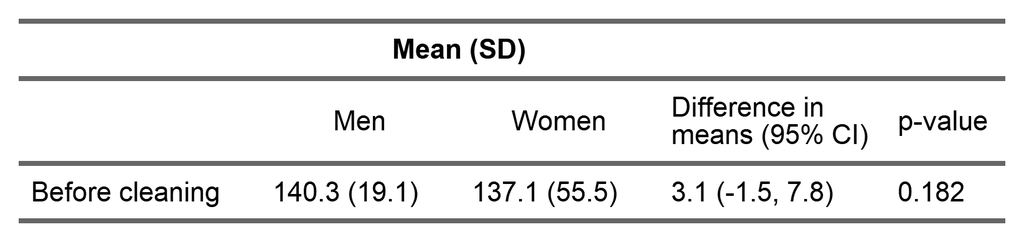

Can **‘untidy’** data affect analyses?

## Transforming data

**Usually influenced by statistical concepts**

1. Implausible values
2. Extreme values or outliers
3. Inconsistent values
4. Transforming and recoding variables

## Transforming data

**Implausible values**

Values that could not possible be true

- SBP of 220 mmHg is *unusual* but possible
- SBP of 540 mmHg is is *physiologically impossible*

Recording error?

If not able to find *true* value, set as missing

## Transforming data

**Implausible values**

*Before data cleaning*

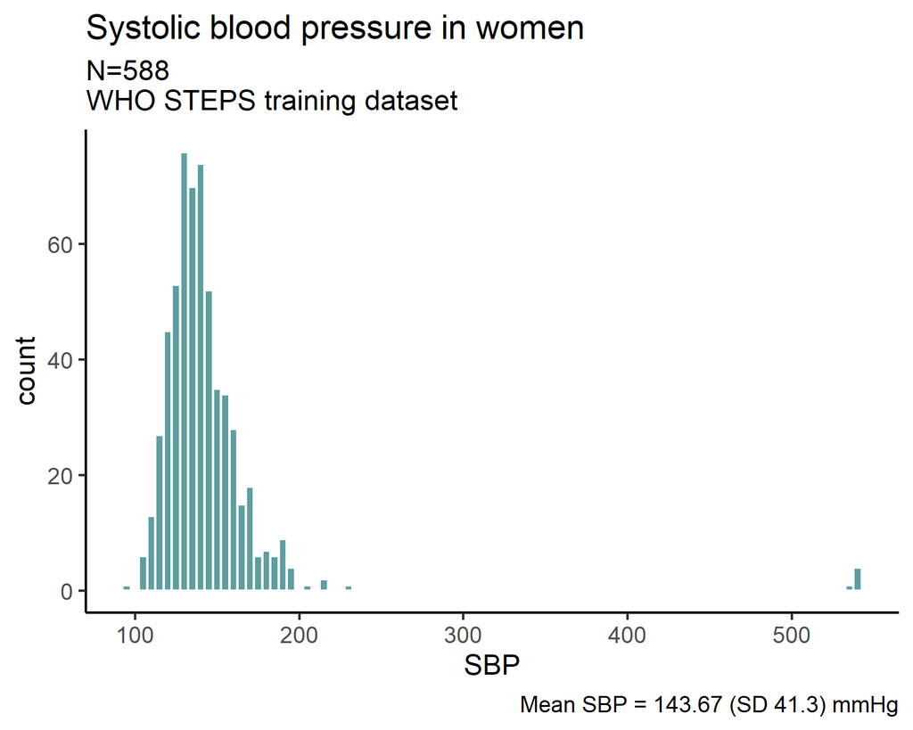

## Transforming data

**Implausible values**

*After data cleaning*

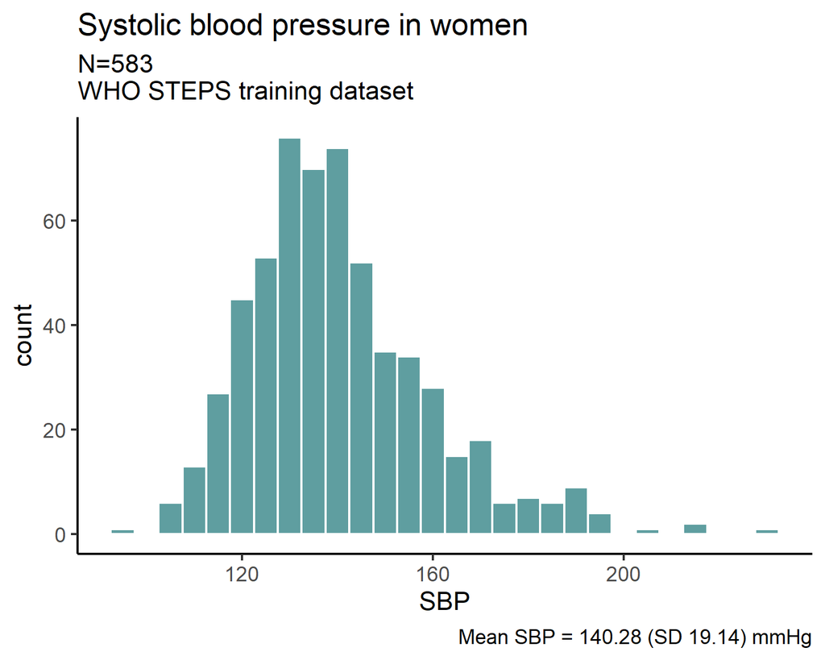

## Transforming data

**Implausible values**

Does SBP vary in men and women?

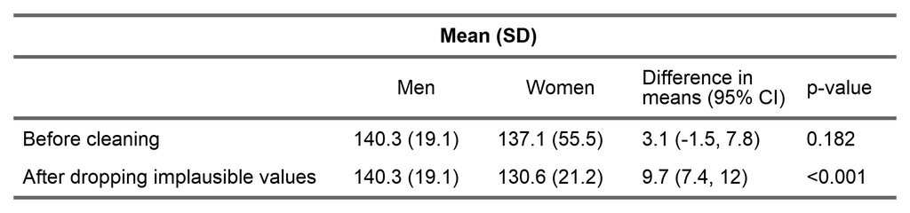

## Transforming data

**Extreme values or “outliers”**

- Values outside the *usual* range for the variable
  - But values are plausible
- Judgement call (*subjective*)
  - Define cut-offs
- Inspect distributions first

## Transforming data

**Extreme values or “outliers”**

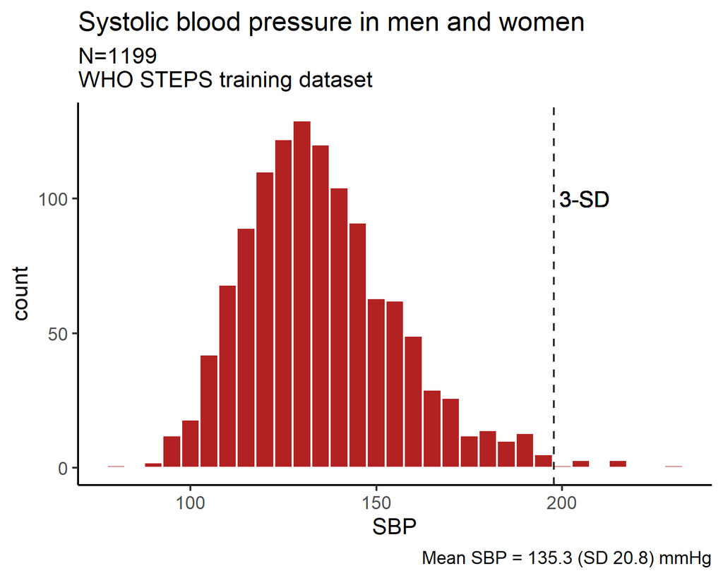

## Transforming data

**Extreme values or “outliers”**

[figure not shown]

## Transforming data

**Extreme values or “outliers”**

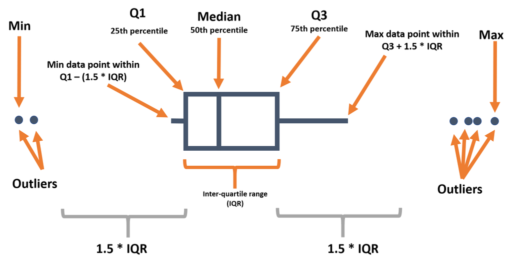

## Transforming data

**Implausible values**

Does SBP vary in men and women?

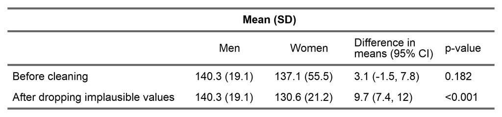

## Transforming data

**Extreme values or “outliers”**

- Certain statistical tests are unduly influenced by outliers  
- Removing these values requires careful consideration

**What are the possible issues with this approach?**

If values plausible:  
- Would omit information from analyses  
- Limits generalisability of results  
- Could look like ‘fixing’ your data  
**If extreme values removed, this need to be clearly documented and reported (justify decision)**

## Transforming data

**Inconsistent values**

## Transforming data

**Coding issues**

## Transforming data

**Transforming and recoding variables**

## Selecting data

```
##     sex           sbp
##  Men  :400   Min.   : 64.0
##  Women:400   1st Qu.:120.0
##              Median :134.0
##              Mean   :133.8
##              3rd Qu.:147.0
##              Max.   :208.0
```

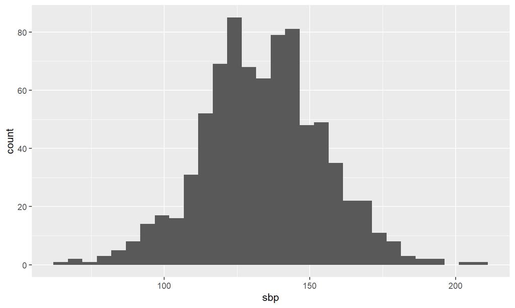

## Slide with a table

| Right | Left | Default | Centre |
| --- | --- | --- | --- |
| 12 | 12 | 12 | 12 |
| 123 | 123 | 123 | 123 |
| 1 | 1 | 1 | 1 |

## Slide with Animation

## What *is* data cleaning?

Conceptually:

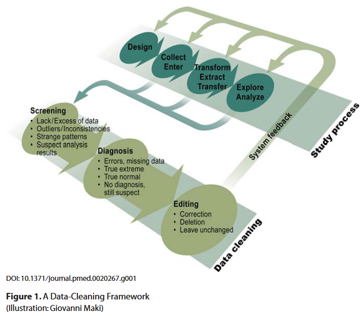

## Ethical considerations of data cleaning

> *“Data cleaning can* *never* *be a cure for poor study design or study conduct. Concerns about where to draw the line between* *data manipulation* *and* *responsible data editing* *are legitimate. Yet all studies, no matter how well designed and implemented, have to deal with errors from various sources and their effects on study results.”*

> *“…description of data cleaning”* should *“be a standard part of reporting statistical methods.”* (Broeck et al. 2005)

## Reproducible Research

Replication is hard, but necessary for better science!

Scripting **everything** is essential for reproducible research.

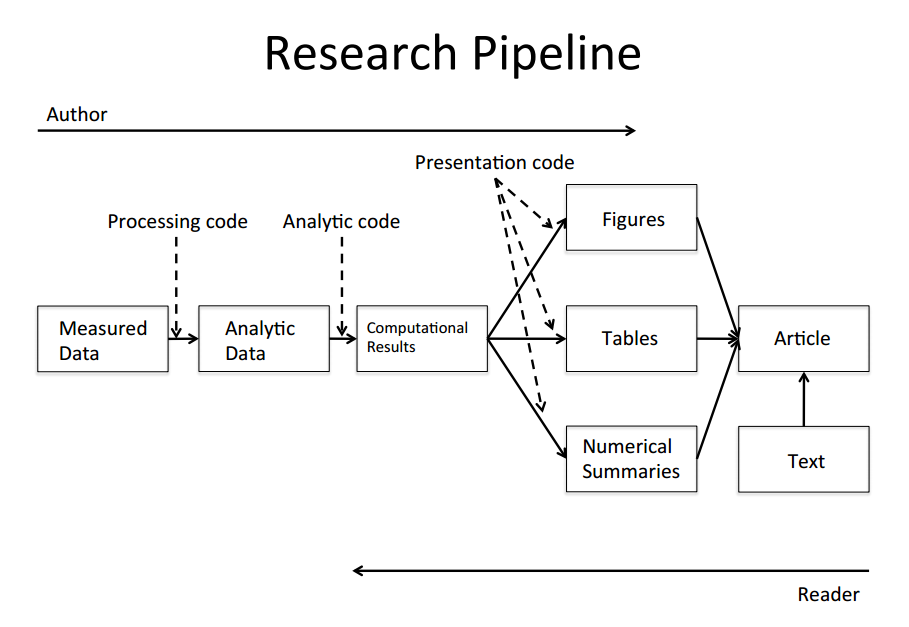

## Sources for creating Rmd slides

- https://bookdown.org/yihui/rmarkdown/ioslides-presentation.html

## Bibliography

Broeck, Jan Van den, Solveig Argeseanu Cunningham, Roger Eeckels, and Kobus Herbst. 2005. “Data Cleaning: Detecting, Diagnosing, and Editing Data Abnormalities.” *PLOS Medicine* 2 (10): e267. https://doi.org/10.1371/journal.pmed.0020267.